# Optimal MPAs

Ernesto Carrella

January 4, 2016

# Optimal MPAs with Bayesian Optimization

Here is a very simple application of Bayesian Optimization when it comes to find an optimal policy. Imagine that the only policy we are allowed to impose is a MPA. We can choose where to place it, how big to make it but it cannot include season closures, tradeable quotas and the likes.  
Imagine further that there are two species, reds and blues, and we want to maximize the number of reds we catch and the number of blues surviving.

Depending on how we weight those two directives and the biology of the world we can find the “optimal” MPA.  
Defining an MPA as a rectangle this problem can be translated into a 4 dimensional optimization: maximize policy score by modifying the $x$ and the $y$ top-left coordinate of the MPA plus its $\text{height}$ and $\text{width}$.

## Trivial case

Imagine we care only about blue fish surviving, so our policy score is:
$$\text{Score} = \text{Blue Biomass}_{t=20}$$
Imagine further that the world is perfectly separated and blue fish live on the south of the sea and red fish live on the north side.

[video not shown]

It should be obvious that any MPA that covers the south part of the sea is going to be optimal. Because there is no mention of the red fish in the score function however, the MPA can cover any portion of the north part of the sea as well and still be optimal.  
The following is the MPA discovered by the Bayesian optimizer, large but optimal as it covers all the blue area

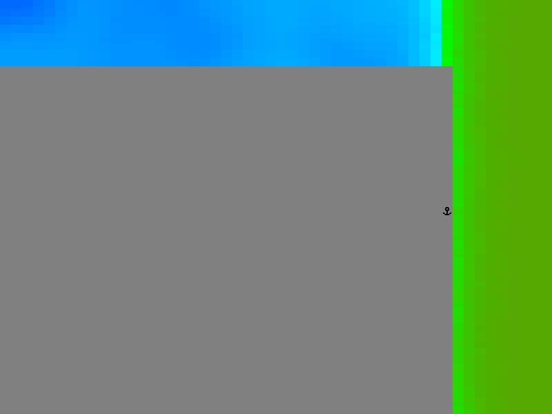

## Slightly less than trivial case

Imagine now that we care about blue fish surviving but also about catching red fish over 20 years of simulation:
$$\text{Score} = \text{Blue Biomass}_{t=20} + \sum_{i=1}^{20}\text{Red Landings}_{t=i}$$
Now clearly the MPA must protect the south part of the sea, but it isn’t obvious what it should do about the north part. If we protect nothing, overfishing will kill off all the reds and the cumulative catch will stay low. It becomes important then to keep at least part of the north sea protected and this is what the optimizer looks for.

The result is an MPA that covers all of the blue area and a small portion of the red one, enough for reds not to go extinct.

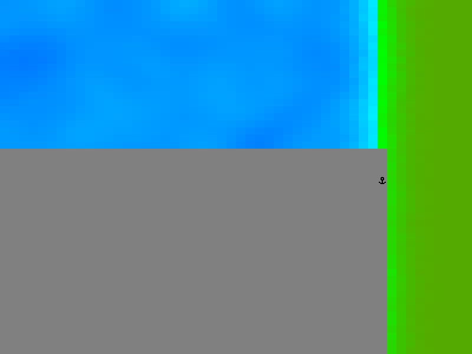

After consuming the unprotected red biomass, fishers live off fishing the line in a way that maximizes the 20 year cumulative red catches.

## Mixed case

What if there is no geographical separation between reds and blues but live together in a 80-20 proportion in every box of the world? When that happens MPA as an instrument is blunted because there is no geographical way to tune the tradeoff between keeping blues alive and catching reds.

It turns out that the solution is a tall but relatively narrow MPA near port.

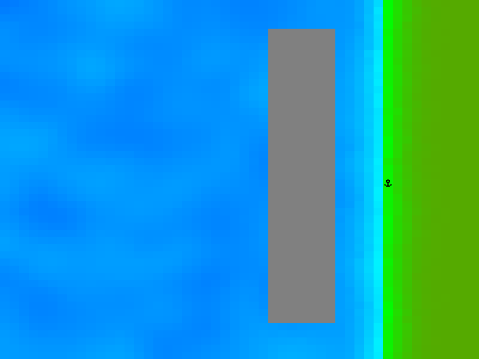

The fish in this area is protected and allowed to repopulate fished out areas. Eventually the Bayesian optimizer is looking for the right size of protected area that will allow, even after years of fishing the line, the most catches of reds against the least catches of blues.

Because it’s a complex problem with an unexpected solution, it’s worth studying the solution space in greater detail. Unfortunately because there are 4 dimensions to this policy (width, height, top-left $x$ and $y$ coordinates) the score posterior discovered by the bayesian optimizer cannot be plotted.  
What I do is take all the 342 observations generated by the bayesian optimizer and feed them into a simple regression tree. Here I am not trying to build another predictive model but just to summarize the optimizer findings and provide an insight on what policies work and what don’t.

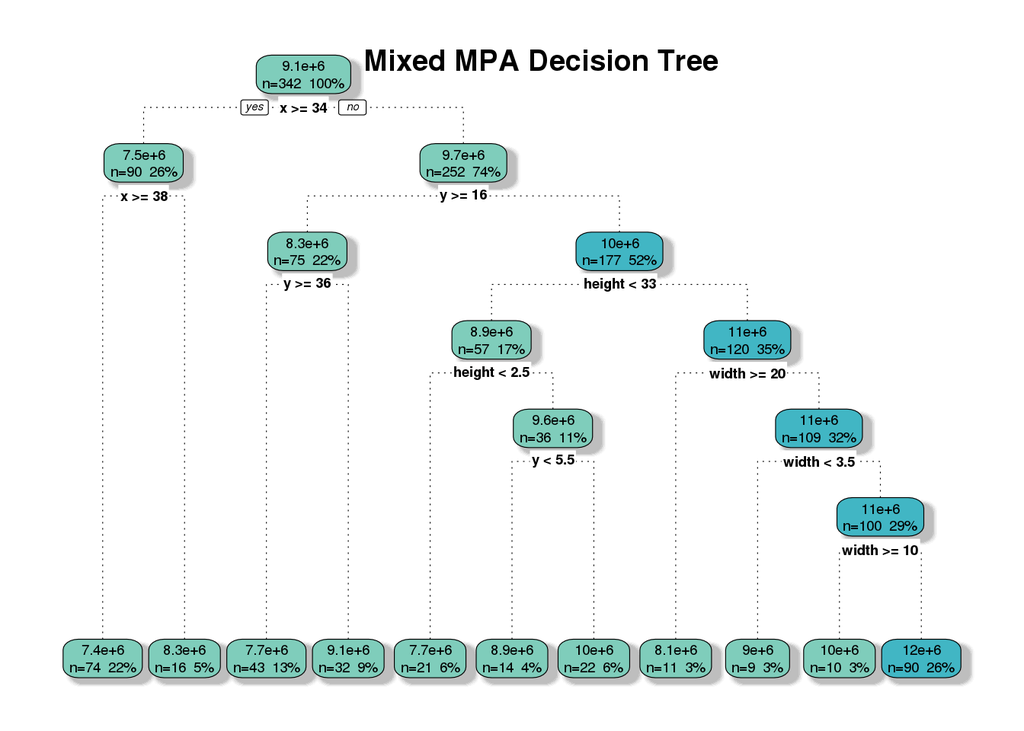